# Statistical Methods and Data Analysis Exam

F517819

```r
# Global rmd setting.
knitr::opts_chunk$set(
  comment = "",
  results = "hold",
  message = FALSE,
  warning = FALSE,
  fig.width = 4.5,
  fig.height = 4.5,
  fig.align = "center"
)
```

```r
library("lindia")
library("MASS")
library("sandwich")
library("investr")
library("car")
library("rio")
library("pROC")
library("nnet")
library("tidyverse")
library("magrittr")
library("here")
library("janitor")
library("readxl")
library("rcompanion")
library("ggcorrplot")
library("corrr")
library("effects")
library("caret")
library("AmesHousing")
library("lme4")
library("merTools")
library("AER")
```

```r
# read both datasets
playerdata <- clean_names(read.csv(here("data", "playerdata.csv"), na = c("?", "", "NA", "N/A", "Na")
))

teamdata <- clean_names(read.csv(here("data", "teamdata.csv"), na = c("?", "", "NA", "N/A", "Na")
))
```

```r
# preview data
glimpse(teamdata)
```

```
Rows: 654
Columns: 52
$ x                <int> 1, 2, 3, 4, 5, 6, 7, 8, 9, 10, 11, 12, 13, 14, 15, 16…
$ year_id          <int> 1995, 1995, 1995, 1995, 1995, 1995, 1995, 1995, 1995,…
$ lg_id            <chr> "NL", "AL", "AL", "AL", "AL", "NL", "NL", "AL", "NL",…
$ team_id          <chr> "ATL", "BAL", "BOS", "CAL", "CHA", "CHN", "CIN", "CLE…
$ franch_id        <chr> "ATL", "BAL", "BOS", "ANA", "CHW", "CHC", "CIN", "CLE…
$ div_id           <chr> "E", "E", "E", "W", "C", "C", "C", "C", "W", "E", "E"…
$ rank             <int> 1, 3, 1, 2, 3, 3, 1, 1, 2, 4, 4, 2, 2, 1, 5, 4, 5, 2,…
$ g                <int> 144, 144, 144, 145, 145, 144, 144, 144, 144, 144, 143…
$ ghome            <int> 72, 72, 72, 72, 72, 72, 72, 72, 72, 72, 71, 72, 72, 7…
$ w                <int> 90, 71, 86, 78, 68, 73, 85, 100, 77, 60, 67, 76, 70, …
$ l                <int> 54, 73, 58, 67, 76, 71, 59, 44, 67, 84, 76, 68, 74, 6…
$ div_win          <chr> "Y", "N", "Y", "N", "N", "N", "Y", "Y", "N", "N", "N"…
$ wc_win           <chr> "N", "N", "N", "N", "N", "N", "N", "N", "Y", "N", "N"…
```

[output cut: 39 more lines]

```r
# review data
glimpse(playerdata)
```

```
Rows: 1,982
Columns: 42
$ year_id    <int> 1985, 1985, 1985, 1985, 1985, 1985, 1985, 1985, 1985, 1985,…
$ team_id    <chr> "ATL", "ATL", "ATL", "ATL", "ATL", "ATL", "ATL", "ATL", "AT…
$ lg_id      <chr> "NL", "NL", "NL", "NL", "NL", "NL", "NL", "NL", "NL", "NL",…
$ player_id  <chr> "barkele01", "bedrost01", "benedbr01", "campri01", "ceronri…
$ salary     <int> 870000, 550000, 545000, 633333, 625000, 800000, 150000, 483…
$ stint      <int> 1, 1, 1, 1, 1, 1, 1, 1, 1, 1, 1, 1, 1, 1, 1, 1, 1, 1, 1, 1,…
$ pos        <chr> "P", "P", "C", "P", "C", "1B", "P", "P", "P", "OF", "1B", "…
$ g          <int> 20, 37, 70, 66, 91, 39, 60, 46, 59, 131, 87, 40, 140, 39, 1…
$ gs         <int> 18, 37, 67, 2, 76, 27, 0, 0, 0, 124, 85, 40, 130, 39, 6, 11…
$ inn_outs   <int> 221, 620, 1698, 383, 2097, 814, 258, 178, 292, 3299, 2239, …
$ po         <int> 2, 13, 314, 7, 384, 299, 9, 2, 11, 215, 892, 25, 339, 21, 2…
$ a          <int> 9, 23, 35, 13, 48, 25, 27, 7, 17, 10, 58, 61, 539, 45, 12, …
$ e          <int> 1, 4, 4, 4, 6, 1, 2, 1, 0, 5, 0, 11, 10, 4, 2, 8, 7, 1, 11,…
```

[output cut: 29 more lines]

# Question 1

## a)

```r
# create log base 10 of team salaries
teamdata <- teamdata %>%
  mutate(log10meansalary = log10(meansalary))
```

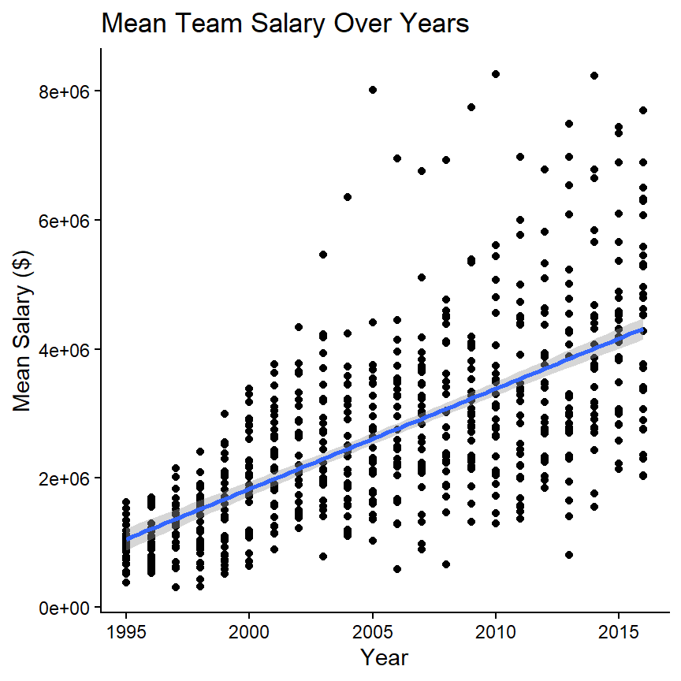

```r
# Raw mean salary over years
teamdata %>%
  ggplot(aes(x = year_id, y = meansalary)) +
  geom_point() +
  geom_smooth(method = "lm") +
  labs(x = "Year", y = "Mean Salary ($)") +
  ggtitle("Mean Team Salary Over Years") +
  theme_classic()
```

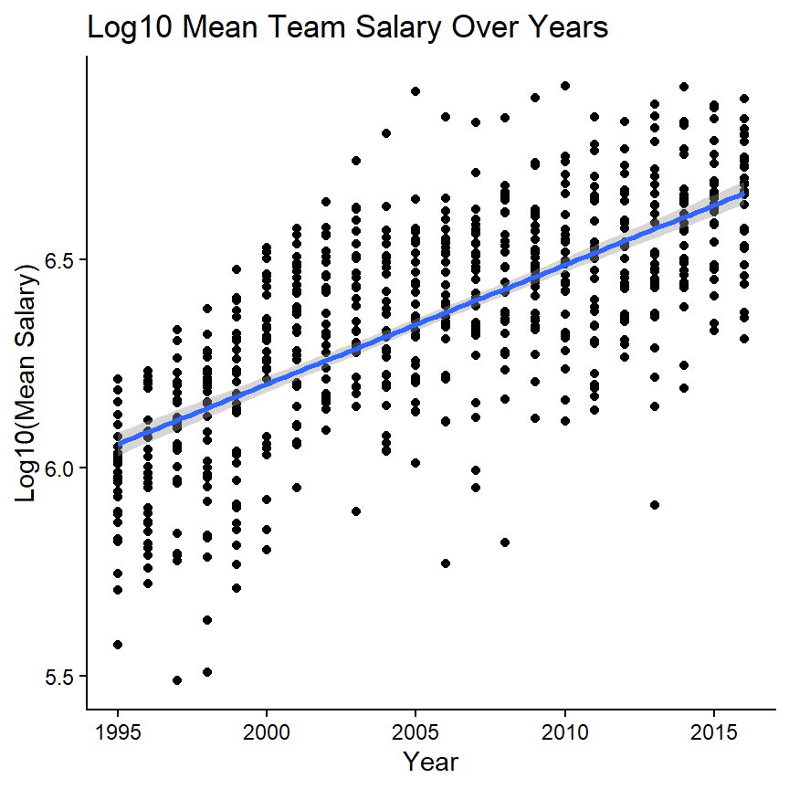

```r
# Log10 mean salary over years
teamdata %>%
  ggplot(aes(x = year_id, y = log10meansalary)) +
  geom_point() +
  geom_smooth(method = "lm") +
  labs(x = "Year", y = "Log10(Mean Salary)") +
  ggtitle("Log10 Mean Team Salary Over Years") +
  theme_classic()
```

Two reasons why linear model is more appropriate for log base 10 mean salaries than for raw mean salaries:

- Reduced skewness: taking logs compresses the largest values and makes the data more symmetric.
- Homoscedasticity: the raw salary plot shows increasing spread in later years. Log10 stabilises this variance, making it roughly constant across all years, satisfying the constant variance assumption.

## b)

```r
# fit the model
linmod1 <- lm(log10meansalary ~ year_id, data = teamdata)
summary(linmod1)
```

```
Call:
lm(formula = log10meansalary ~ year_id, data = teamdata)

Residuals:
     Min       1Q   Median       3Q      Max
-0.66345 -0.11692  0.00644  0.13394  0.55976

Coefficients:
              Estimate Std. Error t value Pr(>|t|)
(Intercept) -51.222416   2.310867  -22.17   <2e-16 ***
year_id       0.028711   0.001152   24.92   <2e-16 ***
---
Signif. codes:  0 '***' 0.001 '**' 0.01 '*' 0.05 '.' 0.1 ' ' 1

Residual standard error: 0.1858 on 652 degrees of freedom
Multiple R-squared:  0.4878,    Adjusted R-squared:  0.487
F-statistic: 620.9 on 1 and 652 DF,  p-value: < 2.2e-16
```

Form of the model:

$$\log_{10}(\text{meansalary}) = -51.222 +
0.02871 \times \text{yearID}$$
The Multiple R-Squared is 0.4878, meaning that 48.78% of the variation in log10 mean salary is explained by year. This suggests year is a moderately strong predictor of mean salary but incomplete.

## c)

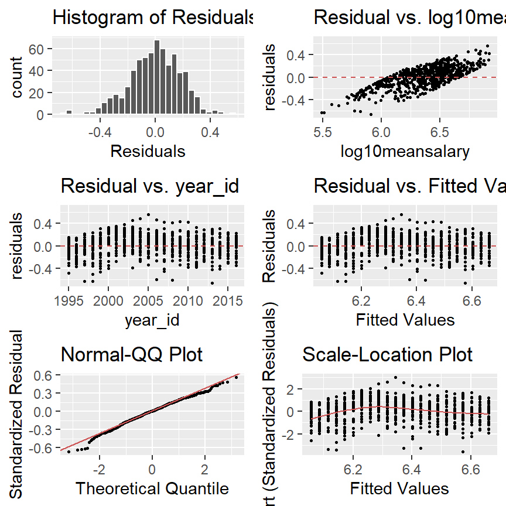

```r
linmod1_plots <- linmod1 %>%
  gg_diagnose(max.per.page = 1, plot.all = FALSE)
plot_all(linmod1_plots[1:6])
```

- Linearity: the residual vs. year_id plot shows points randomly scattered around 0 with no clear curved pattern, suggesting the linearity assumption is satisfied.
- Normality of residuals: the histogram of residuals is roughly bell-shaped and centred around 0. The Normal-QQ plot shows points following the red diagonal line closely, with only slight deviation at the tails. The normality assumption is reasonably satisfied, with some room for improvement.

Homoscedasticity: the residuals vs. fitted values plot shows the spread of residuals is roughly constant across all fitted values, with no obvious fanning in or out. The scale-location plot shows the standardised residuals are spread fairly evenly. The homoscedasticity assumption is satisfied.

## d)

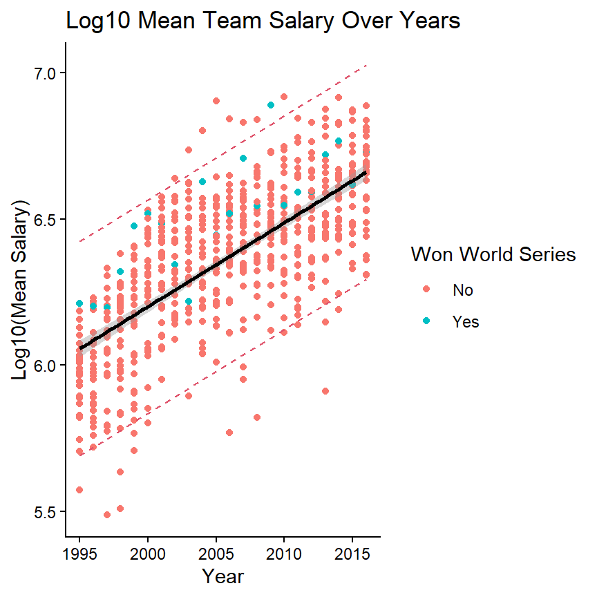

```r
# compute prediction bands
pred1 <- predict(linmod1, interval = "prediction")

# add prediction bands to dataset
myteamdata <- cbind(teamdata, pred1)

# plot with confidence and prediction bands, coloured by World Series winner
myteamdata %>%
  ggplot(mapping = aes(x = year_id, y = log10meansalary, colour = ws_win)) +
  geom_point() +
  geom_smooth(method = lm, colour = "black") +
  geom_line(aes(y = lwr), colour = 2, lty = 2) +
  geom_line(aes(y = upr), colour = 2, lty = 2) +
  labs(x = "Year", y = "Log10(Mean Salary)", colour = "Won World Series") +
  scale_colour_discrete(labels = c("N" = "No", "Y" = "Yes")) +
  ggtitle("Log10 Mean Team Salary Over Years") +
  theme_classic()
```

The confidence band is very narrow, reflecting low uncertainty in the estimated mean log10 salary for a given year. The prediction band is considerably wider, as it accounts for uncertainty in the estimate of the mean and the variance in the residuals. Teams that won the World Series often had higher than average salaries compared with other teams in the same season, however, high salary does not guarantee winning.

## e)

```r
# find info for points above the upper prediction band
above_band <- myteamdata %>%
  filter(log10meansalary > upr) %>%
  select(year_id, team_id, name, meansalary, log10meansalary, upr, ws_win)

above_band
```

```
    year_id team_id             name meansalary log10meansalary      upr ws_win
223    2002     NYA New York Yankees    4342365        6.637726 6.623120      N
253    2003     NYA New York Yankees    5455351        6.736823 6.651788      N
283    2004     NYA New York Yankees    6351516        6.802877 6.680470      N
312    2005     NYA New York Yankees    8011801        6.903730 6.709166      N
342    2006     NYA New York Yankees    6952253        6.842126 6.737876      N
372    2007     NYA New York Yankees    6759252        6.829899 6.766601      N
402    2008     NYA New York Yankees    6929893        6.840727 6.795339      N
432    2009     NYA New York Yankees    7748046        6.889192 6.824091      Y
462    2010     NYA New York Yankees    8253336        6.916630 6.852857      N
```

All points above the upper prediction band relate to the New York Yankees (NYA). This indicates that the Yankees had exceptionally high mean salaries and were systematic outliers. Despite this, they only won the World Series once, suggesting that a very high mean salary might not be a good predictor for World Series winning.

# 2

## a)

```r
# create OnBase dataset of players with at least one hit
OnBase <- playerdata %>%
  filter(h >= 1) %>%
  mutate(year = as.factor(year_id))

# fit Poisson model of runs as a function of hits, year, position, height and age
glm1 <- glm(r ~ h + year + pos + height + age,
            data = OnBase,
            family = "poisson")

summary(glm1)
```

```
Call:
glm(formula = r ~ h + year + pos + height + age, family = "poisson",
    data = OnBase)

Coefficients:
              Estimate Std. Error z value Pr(>|z|)
(Intercept)  2.494e+00  1.692e-01  14.743  < 2e-16 ***
h            1.285e-02  8.953e-05 143.571  < 2e-16 ***
year2015     2.231e-02  9.285e-03   2.402  0.01629 *
pos2B       -1.152e-02  1.671e-02  -0.689  0.49063
pos3B        5.319e-03  1.574e-02   0.338  0.73535
posC        -6.297e-02  2.074e-02  -3.036  0.00239 **
posOF        6.322e-02  1.319e-02   4.792 1.65e-06 ***
posP        -1.171e+00  3.710e-02 -31.556  < 2e-16 ***
posSS       -1.123e-02  1.754e-02  -0.640  0.52207
height      -3.584e-03  2.241e-03  -1.599  0.10982
age          4.693e-03  1.202e-03   3.904 9.47e-05 ***
---
Signif. codes:  0 '***' 0.001 '**' 0.01 '*' 0.05 '.' 0.1 ' ' 1

(Dispersion parameter for poisson family taken to be 1)

    Null deviance: 38805.9  on 1481  degrees of freedom
Residual deviance:  5695.8  on 1471  degrees of freedom
AIC: 12616

Number of Fisher Scoring iterations: 5
```

## b)

```r
# Likelihood Ratio Test for each predictor
car::Anova(glm1, test = "LR")
```

```
Analysis of Deviance Table (Type II tests)

Response: r
       LR Chisq Df Pr(>Chisq)
h       21541.0  1  < 2.2e-16 ***
year        5.8  1    0.01625 *
pos      1584.5  6  < 2.2e-16 ***
height      2.6  1    0.10994
age        15.2  1  9.705e-05 ***
---
Signif. codes:  0 '***' 0.001 '**' 0.01 '*' 0.05 '.' 0.1 ' ' 1
```

Each p-value tests the null hypothesis $H_o$ that the predictor has no effect on the number of runs, against the alternative $H_1$ that at least one coefficient is non-zero, after accounting for all other predictors in the model. A p-value is the probability of observing a test statistic as extreme as, or more extreme than, the one calculated from the data, assuming the null hypothesis is true. A small p-value (< 0.05) gives evidence against the null hypothesis.

The most important predictor is hits with a p-value < 2.2e-16, giving very strong evidence of an effect on runs scored. Equally, pos has a p-value < 2.2e-16, giving very strong evidence that position significantly affects runs. Age is also significant with a p-value of 9.705e-05, giving strong evidence of an effect. Year is marginally significant with a p-value of 0.016, suggesting a small difference in runs between 1985 and 2015. Finally, height has a p-value of 0.110, which is above 0.05, meaning there is insufficient evidence that height has any significant effect on runs scored after accounting for the other predictors.

## c)

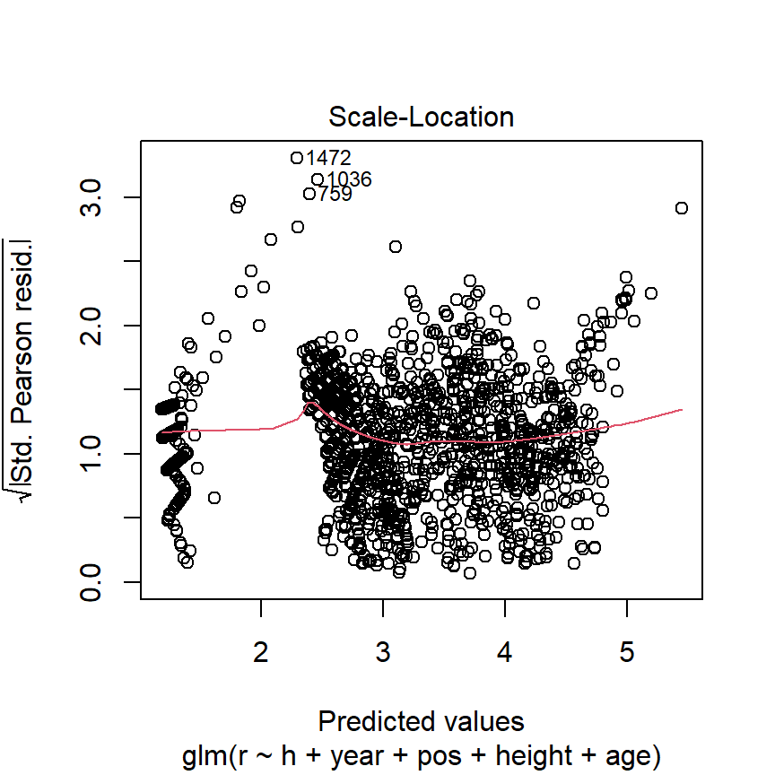

```r
# scale-location plot to assess dispersion assumption
plot(glm1, which = 3)
```

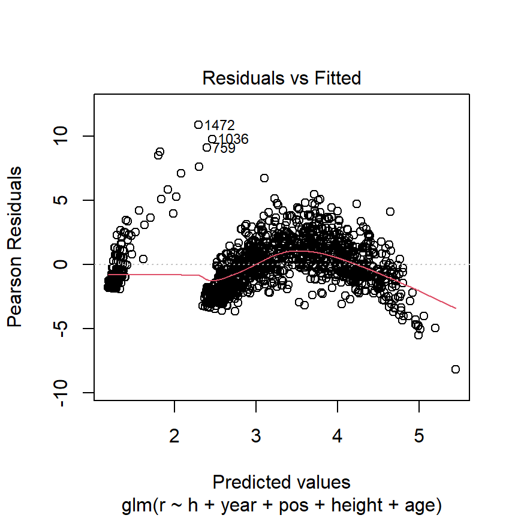

```r
# linearity - residuals vs fitted
plot(glm1, which = 1)
```

```r
# dispersion test
dispersiontest(glm1)
```

```
    Overdispersion test

data:  glm1
z = 14.877, p-value < 2.2e-16
alternative hypothesis: true dispersion is greater than 1
sample estimates:
dispersion
   3.71221
```

- Dispersion: The scale-location plot shows the red line is somewhat flat and horizontal, however it rises slightly in the middle and at the end tail, suggesting the equidispersion assumption is not perfectly satisfied. This is confirmed by the dispersion test, which gives a dispersion estimate of 3.71 and a p-value < 2.2e-16, providing very strong evidence of overdispersion. A quasipoisson or negative binomial model may be more appropriate.
- Residuals: The residuals versus fitted values plot shows a clear curved pattern rather than random scatter around zero. This suggests that the Poisson model does not fully capture the relationship between the predictors and the number of runs.

## d)

```r
# fit mixed effects Poisson model with teamID as random effect
glm2 <- glmer(r ~ h + year + pos + height + age + (1 | team_id),
              data = OnBase,
              family = "poisson",
              nAGQ = 0)
glm2
```

```
Generalized linear mixed model fit by maximum likelihood (Adaptive
  Gauss-Hermite Quadrature, nAGQ = 0) [glmerMod]
 Family: poisson  ( log )
Formula: r ~ h + year + pos + height + age + (1 | team_id)
   Data: OnBase
      AIC       BIC    logLik -2*log(L)  df.resid
12286.451 12350.065 -6131.225 12262.451      1470
Random effects:
 Groups  Name        Std.Dev.
 team_id (Intercept) 0.0965
Number of obs: 1482, groups:  team_id, 33
Fixed Effects:
(Intercept)            h     year2015        pos2B        pos3B         posC
   2.617294     0.012997     0.031966    -0.009808     0.009049    -0.062753
      posOF         posP        posSS       height          age
   0.065600    -1.138439    -0.010986    -0.005710     0.004783
```

```r
# test significance of random effect
anova(glm1, glm2)
```

```
Analysis of Deviance Table

Model: poisson, link: log

Response: r

Terms added sequentially (first to last)

       Df Deviance Resid. Df Resid. Dev  Pr(>Chi)
NULL                    1481      38806
h       1  31439.1      1480       7367 < 2.2e-16 ***
year    1      3.6      1479       7363   0.05786 .
pos     6   1649.7      1473       5714 < 2.2e-16 ***
height  1      2.6      1472       5711   0.10552
age     1     15.2      1471       5696 9.705e-05 ***
---
Signif. codes:  0 '***' 0.001 '**' 0.01 '*' 0.05 '.' 0.1 ' ' 1
```

Form of the model:

$$\log(E(R)) = \beta_0 + \beta_1 H_i +
\beta_2 \text{Year}_i + \beta_3 \text{POS}_i + \beta_4 \text{Height}_i +
\beta_5 \text{Age}_i + b_{\text{team}(i)}, \quad b_{\text{team}(i)} \sim
N(0,\sigma^2_{\text{team}})$$

The random effect for teamID has a standard deviation of 0.0965, indicating that after accounting for hits, year, position, height and age, there is relatively little variation between teams in their baseline run scoring on the log scale. Therefore, team appears to have a relatively small practical effect on the number of runs scored. However, including teamID as a random effect reduced the AIC from 12616 to 12286, a decrease of approximately 330. This indicates a substantial improvement in model fit and provides strong evidence that team contributes to explaining variation in runs scored, even though the team-to-team variation is relatively small.

## e)

```r
predict(glm2,
        newdata = data.frame(
          h = 20,
          year = as.factor("2015"),
          pos = "OF",
          height = 72,
          age = 30,
          team_id = "BAL"
        ),
        type = "response")
```

```
      1
17.5339
```

# 3

## a)

```r
set.seed(123)
training_samples <- c(teamdata$div_win) %>%
  createDataPartition(p = 0.75, list = FALSE)

train_data <- teamdata[training_samples, ]
test_data <- teamdata[-training_samples, ]
```

## b)

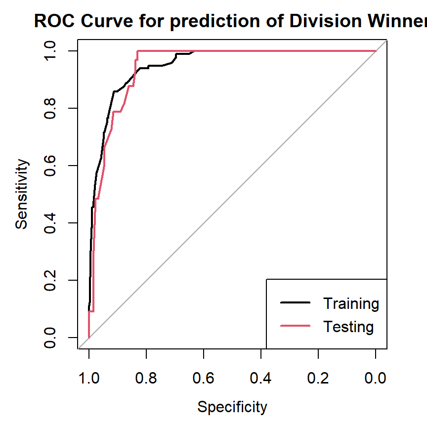

```
Call:
roc.default(response = test_data$div_win, predictor = predtest,     auc = TRUE, plot = TRUE, add = TRUE, col = 2)

Data: predtest in 130 controls (test_data$div_win N) < 33 cases (test_data$div_win Y).
Area under the curve: 0.945
```

```r
# fit logistic model on training data
train_model <- glm(as.factor(div_win) ~ w + l,
                   data = train_data,
                   family = "binomial")

# predict on training and testing data
predtrain <- predict(train_model, type = "response")
predtest <- predict(train_model, newdata = test_data, type = "response")

# ROC curves plots for training and testing data
roctrain <- roc(response = train_data$div_win, predictor = predtrain,
                plot = TRUE,
                main = "ROC Curve for prediction of Division Winner",
                auc = TRUE)

roc(response = test_data$div_win, predictor = predtest,
    plot = TRUE, add = TRUE, col = 2,
    auc = TRUE)

legend("bottomright",
       legend = c("Training", "Testing"),
       col = c(1, 2), lwd = 2)
```

The ROC curves for the training and testing datasets are both well above the diagonal reference line and are very similar in shape, indicating strong predictive performance and little evidence of overfitting. The testing AUC is 0.945, which is considered an excellent number. Therefore, the model is highly effective at distinguishing division winners from non-winners and appears to generalise well to unseen data.

## c)

```r
# find Youden's index cutoff from training data
youdens <- coords(roctrain, "best", best.method = "youden",
                  ret = c("threshold", "sensitivity", "specificity"))
youdens

# cutoff value
cutoff <- youdens$threshold

# confusion matrix for training data
confusionMatrix(
  as.factor(ifelse(predtrain >= cutoff, "Y", "N")),
  as.factor(train_data$div_win)
)

# confusion matrix for testing data
confusionMatrix(
  as.factor(ifelse(predtest >= cutoff, "Y", "N")),
  as.factor(test_data$div_win)
)
```

```
  threshold sensitivity specificity
1 0.3211807   0.8585859   0.9132653
Confusion Matrix and Statistics

          Reference
Prediction   N   Y
         N 358  14
         Y  34  85

               Accuracy : 0.9022
                 95% CI : (0.8725, 0.927)
    No Information Rate : 0.7984
    P-Value [Acc > NIR] : 3.794e-10

                  Kappa : 0.7177

 Mcnemar's Test P-Value : 0.006099

            Sensitivity : 0.9133
            Specificity : 0.8586
         Pos Pred Value : 0.9624
         Neg Pred Value : 0.7143
             Prevalence : 0.7984
         Detection Rate : 0.7291
   Detection Prevalence : 0.7576
      Balanced Accuracy : 0.8859

       'Positive' Class : N

Confusion Matrix and Statistics

          Reference
Prediction   N   Y
         N 112   4
         Y  18  29

               Accuracy : 0.865
                 95% CI : (0.8028, 0.9134)
    No Information Rate : 0.7975
    P-Value [Acc > NIR] : 0.016952

                  Kappa : 0.6392

 Mcnemar's Test P-Value : 0.005578

            Sensitivity : 0.8615
            Specificity : 0.8788
         Pos Pred Value : 0.9655
         Neg Pred Value : 0.6170
             Prevalence : 0.7975
         Detection Rate : 0.6871
   Detection Prevalence : 0.7117
      Balanced Accuracy : 0.8702

       'Positive' Class : N
```

The model performs well with a testing accuracy of 86.5%. The false negative rate is 12.1% and false positive rate is 13.8% on the testing data, both low and similar, suggesting no strong bias towards either error type. The small drop in accuracy from training (90.2%) to testing (86.5%) indicates the model generalises well with no overfitting. Additonally, The confusion matrix further supports this, with only 4 false negatives and 18 false positives in the testing data.